# CSP-571 Project Spring 24

Kyung Jin Kwak (kkwak4@hawk.iit.edu), Srujan Ramesh (sramesh19@hawk.iit.edu)

## Install necessary libraries

```r
library(ggplot2)
library(dplyr)
library(tidyr)
library(knitr)
```

## Loading & Checking Data

```r
taxi_df <- read.csv("taxi_Trips__2024.csv")
```

```r
head(taxi_df)
```

|  | Trip.ID | Taxi.ID | Trip.Start.Timestamp | Trip.End.Timestamp | Trip.Seconds | Trip.Miles | Pickup.Census.Tract | Dropoff.Census.Tract | Pickup.Community.Area | Dropoff.Community.Area | Fare | Tips | Tolls | Extras | Trip.Total | Payment.Type | Company | Pickup.Centroid.Latitude | Pickup.Centroid.Longitude | Pickup.Centroid.Location | Dropoff.Centroid.Latitude | Dropoff.Centroid.Longitude | Dropoff.Centroid..Location |
| --- | --- | --- | --- | --- | --- | --- | --- | --- | --- | --- | --- | --- | --- | --- | --- | --- | --- | --- | --- | --- | --- | --- | --- |
| 1 | 0000184e7cd53cee95af32eba49c44e4d20adcd8 | f538e6b729d1aaad4230e9dcd9dc2fd9a168826ddadbd67c2f79331875dc586863d73aa3169fb266dc5e5ed6cdc8687537de8071a51556146f5251d4d8e8237f | 1/19/24 17:00 | 1/19/24 18:00 | 4051 | 17.12 | 17031980000 | 17031320100 | 76 | 32 | 45.50 | 10.00 | 0 | 4.0 | 60.00 | Credit Card | Flash Cab | 41.97907 | -87.90304 | POINT (-87.9030396611 41.9790708201) | 41.88499 | -87.62099 | POINT (-87.6209929134 41.8849871918) |
| 2 | 000072ee076c9038868e239ca54185eb43959db0 | e51e2c30caec952b40b8329a68b498e18ce8a1f40fa75c71e425e9426db562ac617b0a28e1c69f5c579048f75a43a2dc066c17448ab65f5016acca10558df3ed | 1/28/24 14:30 | 1/28/24 15:00 | 1749 | 12.70 | NA | NA | 6 | NA | 33.75 | 0.00 | 0 | 0.0 | 33.75 | Cash | Flash Cab | 41.94423 | -87.65600 | POINT (-87.6559981815 41.9442266014) | NA | NA |  |
| 3 | 000074019d598c2b1d6e77fbae79e40b0461a2fc | aeb280ef3be3e27e081eb6e76027615b0d40925b84d3eb1301a01293a34c41ec45fe1ff1ceeb0e769565af1573d216d5a6c8bbc260b9f8a8db9be4ef74d31c78 | 1/5/24 9:00 | 1/5/24 9:00 | 517 | 3.39 | NA | NA | 6 | 8 | 10.91 | 2.78 | 0 | 1.0 | 14.69 | Mobile | Taxicab Insurance Agency Llc | 41.94423 | -87.65600 | POINT (-87.6559981815 41.9442266014) | 41.89960 | -87.63331 | POINT (-87.6333080367 41.899602111) |
| 4 | 00007572c5f92e2ff067e6f838a5ad74e83665d3 | 7d21c2ca227db8f27dda96612bfe5520ab408fa9a462c8ca4c73a22c362b8022ac8e0f5538c9b820dc3a6be61e06f215654909a3b02770ddf84631e948479436 | 1/22/24 8:45 | 1/22/24 9:30 | 2050 | 15.06 | NA | NA | 76 | NA | 39.25 | 11.31 | 0 | 5.5 | 56.56 | Credit Card | Globe Taxi | 41.98026 | -87.91362 | POINT (-87.913624596 41.9802643146) | NA | NA |  |
| 5 | 00007c3e7546e2c7d15168586943a9c22c3856cf | 8ef1056519939d511d24008e394f83e925d2539d668a002c97c441c1d24ab86e29b31a6d8544356006c1eee49dda811760c872d4ddcbaffd55a681b17864a014 | 1/18/24 19:15 | 1/18/24 19:30 | 1004 | 1.18 | 17031839100 | 17031839100 | 32 | 32 | 15.94 | 3.72 | 0 | 0.0 | 19.66 | Mobile | 5 Star Taxi | 41.88099 | -87.63275 | POINT (-87.6327464887 41.8809944707) | 41.88099 | -87.63275 | POINT (-87.6327464887 41.8809944707) |
| 6 | 0000bab44d0d673a222e7f1a0a6026563519aa25 | 833e49f9757b594a8a6765b93d1f7d8ad483e61c3a89d1a808ef40a33940ccaac349d4aec1e6415a079b1bc3a13f186b5af03683e52ed789153e97a3d59557a8 | 1/9/24 17:00 | 1/9/24 17:00 | 12 | 0.18 | NA | NA | 3 | 6 | 3.50 | 0.00 | 0 | 0.0 | 3.50 | Cash | Taxicab Insurance Agency Llc | 41.96581 | -87.65588 | POINT (-87.6558787862 41.96581197) | 41.94423 | -87.65600 | POINT (-87.6559981815 41.9442266014) |

```r
colSums(is.na(taxi_df))
```

```
##                    Trip.ID                    Taxi.ID
##                          0                          1
##       Trip.Start.Timestamp         Trip.End.Timestamp
##                          0                          0
##               Trip.Seconds                 Trip.Miles
##                         87                          5
##        Pickup.Census.Tract       Dropoff.Census.Tract
##                     266886                     273775
##      Pickup.Community.Area     Dropoff.Community.Area
##                      11105                      42428
##                       Fare                       Tips
##                       1014                       1014
##                      Tolls                     Extras
##                       1014                       1014
##                 Trip.Total               Payment.Type
##                       1014                          0
##                    Company   Pickup.Centroid.Latitude
##                          0                      10989
##  Pickup.Centroid.Longitude   Pickup.Centroid.Location
##                      10989                          0
##  Dropoff.Centroid.Latitude Dropoff.Centroid.Longitude
##                      39982                      39982
## Dropoff.Centroid..Location
##                          0
```

```r
(unique(taxi_df$Company))
```

```
##  [1] "Flash Cab"
##  [2] "Taxicab Insurance Agency Llc"
##  [3] "Globe Taxi"
##  [4] "5 Star Taxi"
##  [5] "City Service"
##  [6] "Chicago Independents"
##  [7] "Blue Ribbon Taxi Association"
##  [8] "Taxi Affiliation Services"
##  [9] "Chicago City Taxi Association"
## [10] "Choice Taxi Association"
## [11] "Medallion Leasin"
## [12] "Sun Taxi"
## [13] "U Taxicab"
## [14] "Taxicab Insurance Agency, LLC"
## [15] "Choice Taxi Association Inc"
```

[output cut: 20 more lines]

## Understanding the features

```r
feature_desc <- read.csv("taxi_Trips_2024_Feature_descriptions.csv")
feature_desc
```

| Column.Name | Description | Type |
| --- | --- | --- |
| Trip ID | A unique identifier for the trip. | Plain Text |
| Taxi ID | A unique identifier for the taxi. | Plain Text |
| Trip Start Timestamp | When the trip started, rounded to the nearest 15 minutes. | Date & Time |
| Trip End Timestamp | When the trip ended, rounded to the nearest 15 minutes. | Date & Time |
| Trip Seconds | Time of the trip in seconds. | Number |
| Trip Miles | Distance of the trip in miles. | Number |
| Pickup Census Tract | The Census Tract where the trip began. For privacy, this Census Tract is not shown for some trips. This column often will be blank for locations outside Chicago. | Plain Text |
| Dropoff Census Tract | The Census Tract where the trip ended. For privacy, this Census Tract is not shown for some trips. This column often will be blank for locations outside Chicago. | Plain Text |
| Pickup Community Area | The Community Area where the trip began. This column will be blank for locations outside Chicago. | Number |
| Dropoff Community Area | The Community Area where the trip ended. This column will be blank for locations outside Chicago. | Number |

[output cut: 13 more lines]

```r
notes <- list()
for (feature in names(taxi_df)) {

  curr_note <- paste("Valid rows:",(nrow(taxi_df) - sum(is.na(taxi_df[,feature]))),
                     "; N/A rows:", sum(is.na(taxi_df[,feature])),
                     "; Unique values:", length(unique(taxi_df[,feature])))
  notes <- append(notes, curr_note)
}
notes
```

```
## [[1]]
## [1] "Valid rows: 425229 ; N/A rows: 0 ; Unique values: 425229"
##
## [[2]]
## [1] "Valid rows: 425228 ; N/A rows: 1 ; Unique values: 2520"
##
## [[3]]
## [1] "Valid rows: 425229 ; N/A rows: 0 ; Unique values: 2977"
##
## [[4]]
## [1] "Valid rows: 425229 ; N/A rows: 0 ; Unique values: 2988"
##
## [[5]]
## [1] "Valid rows: 425142 ; N/A rows: 87 ; Unique values: 6077"
##
## [[6]]
## [1] "Valid rows: 425224 ; N/A rows: 5 ; Unique values: 4278"
##
## [[7]]
## [1] "Valid rows: 158343 ; N/A rows: 266886 ; Unique values: 221"
##
## [[8]]
## [1] "Valid rows: 151454 ; N/A rows: 273775 ; Unique values: 347"
##
## [[9]]
## [1] "Valid rows: 414124 ; N/A rows: 11105 ; Unique values: 78"
##
## [[10]]
## [1] "Valid rows: 382801 ; N/A rows: 42428 ; Unique values: 78"
##
## [[11]]
## [1] "Valid rows: 424215 ; N/A rows: 1014 ; Unique values: 4642"
##
## [[12]]
## [1] "Valid rows: 424215 ; N/A rows: 1014 ; Unique values: 2161"
##
## [[13]]
## [1] "Valid rows: 424215 ; N/A rows: 1014 ; Unique values: 139"
##
## [[14]]
```

[output cut: 13 more lines]

```
##
## [[19]]
## [1] "Valid rows: 414240 ; N/A rows: 10989 ; Unique values: 276"
##
## [[20]]
## [1] "Valid rows: 425229 ; N/A rows: 0 ; Unique values: 277"
##
## [[21]]
## [1] "Valid rows: 385247 ; N/A rows: 39982 ; Unique values: 366"
##
## [[22]]
## [1] "Valid rows: 385247 ; N/A rows: 39982 ; Unique values: 365"
##
## [[23]]
## [1] "Valid rows: 425229 ; N/A rows: 0 ; Unique values: 366"
```

```r
feature_desc$Notes <- unlist(notes)
feature_desc
```

| Column.Name | Description | Type | Notes |
| --- | --- | --- | --- |
| Trip ID | A unique identifier for the trip. | Plain Text | Valid rows: 425229 ; N/A rows: 0 ; Unique values: 425229 |
| Taxi ID | A unique identifier for the taxi. | Plain Text | Valid rows: 425228 ; N/A rows: 1 ; Unique values: 2520 |
| Trip Start Timestamp | When the trip started, rounded to the nearest 15 minutes. | Date & Time | Valid rows: 425229 ; N/A rows: 0 ; Unique values: 2977 |
| Trip End Timestamp | When the trip ended, rounded to the nearest 15 minutes. | Date & Time | Valid rows: 425229 ; N/A rows: 0 ; Unique values: 2988 |
| Trip Seconds | Time of the trip in seconds. | Number | Valid rows: 425142 ; N/A rows: 87 ; Unique values: 6077 |
| Trip Miles | Distance of the trip in miles. | Number | Valid rows: 425224 ; N/A rows: 5 ; Unique values: 4278 |
| Pickup Census Tract | The Census Tract where the trip began. For privacy, this Census Tract is not shown for some trips. This column often will be blank for locations outside Chicago. | Plain Text | Valid rows: 158343 ; N/A rows: 266886 ; Unique values: 221 |
| Dropoff Census Tract | The Census Tract where the trip ended. For privacy, this Census Tract is not shown for some trips. This column often will be blank for locations outside Chicago. | Plain Text | Valid rows: 151454 ; N/A rows: 273775 ; Unique values: 347 |
| Pickup Community Area | The Community Area where the trip began. This column will be blank for locations outside Chicago. | Number | Valid rows: 414124 ; N/A rows: 11105 ; Unique values: 78 |
| Dropoff Community Area | The Community Area where the trip ended. This column will be blank for locations outside Chicago. | Number | Valid rows: 382801 ; N/A rows: 42428 ; Unique values: 78 |

[output cut: 13 more lines]

```r
# Install the formattable package if not already installed
if (!require(formattable)) {
  install.packages("formattable")
}
# Load the formattable package
library(formattable)

# Pretty print the table with color
formattable(feature_desc, align = c("l", "l", "l", "l"), list(Notes = formatter("span", style = "color:blue"), Type = formatter("span", style = "color:green"))
)
```

| Column.Name | Description | Type | Notes |
| --- | --- | --- | --- |
| Trip ID | A unique identifier for the trip. | Plain Text | Valid rows: 425229 ; N/A rows: 0 ; Unique values: 425229 |
| Taxi ID | A unique identifier for the taxi. | Plain Text | Valid rows: 425228 ; N/A rows: 1 ; Unique values: 2520 |
| Trip Start Timestamp | When the trip started, rounded to the nearest 15 minutes. | Date & Time | Valid rows: 425229 ; N/A rows: 0 ; Unique values: 2977 |
| Trip End Timestamp | When the trip ended, rounded to the nearest 15 minutes. | Date & Time | Valid rows: 425229 ; N/A rows: 0 ; Unique values: 2988 |
| Trip Seconds | Time of the trip in seconds. | Number | Valid rows: 425142 ; N/A rows: 87 ; Unique values: 6077 |
| Trip Miles | Distance of the trip in miles. | Number | Valid rows: 425224 ; N/A rows: 5 ; Unique values: 4278 |
| Pickup Census Tract | The Census Tract where the trip began. For privacy, this Census Tract is not shown for some trips. This column often will be blank for locations outside Chicago. | Plain Text | Valid rows: 158343 ; N/A rows: 266886 ; Unique values: 221 |
| Dropoff Census Tract | The Census Tract where the trip ended. For privacy, this Census Tract is not shown for some trips. This column often will be blank for locations outside Chicago. | Plain Text | Valid rows: 151454 ; N/A rows: 273775 ; Unique values: 347 |
| Pickup Community Area | The Community Area where the trip began. This column will be blank for locations outside Chicago. | Number | Valid rows: 414124 ; N/A rows: 11105 ; Unique values: 78 |
| Dropoff Community Area | The Community Area where the trip ended. This column will be blank for locations outside Chicago. | Number | Valid rows: 382801 ; N/A rows: 42428 ; Unique values: 78 |
| Fare | The fare for the trip. | Number | Valid rows: 424215 ; N/A rows: 1014 ; Unique values: 4642 |
| Tips | The tip for the trip. Cash tips generally will not be recorded. | Number | Valid rows: 424215 ; N/A rows: 1014 ; Unique values: 2161 |
| Tolls | The tolls for the trip. | Number | Valid rows: 424215 ; N/A rows: 1014 ; Unique values: 139 |
| Extras | Extra charges for the trip. | Number | Valid rows: 424215 ; N/A rows: 1014 ; Unique values: 865 |
| Trip Total | Total cost of the trip, the total of the previous columns. | Number | Valid rows: 424215 ; N/A rows: 1014 ; Unique values: 7816 |
| Payment Type | Type of payment for the trip. | Plain Text | Valid rows: 425229 ; N/A rows: 0 ; Unique values: 7 |
| Company | The taxi company. | Plain Text | Valid rows: 425229 ; N/A rows: 0 ; Unique values: 35 |
| Pickup Centroid Latitude | The latitude of the center of the pickup census tract or the community area if the census tract has been hidden for privacy. This column often will be blank for locations outside Chicago. | Number | Valid rows: 414240 ; N/A rows: 10989 ; Unique values: 276 |
| Pickup Centroid Longitude | The longitude of the center of the pickup census tract or the community area if the census tract has been hidden for privacy. This column often will be blank for locations outside Chicago. | Number | Valid rows: 414240 ; N/A rows: 10989 ; Unique values: 276 |
| Pickup Centroid Location | The location of the center of the pickup census tract or the community area if the census tract has been hidden for privacy. This column often will be blank for locations outside Chicago. | Point | Valid rows: 425229 ; N/A rows: 0 ; Unique values: 277 |
| Dropoff Centroid Latitude | The latitude of the center of the dropoff census tract or the community area if the census tract has been hidden for privacy. This column often will be blank for locations outside Chicago. | Number | Valid rows: 385247 ; N/A rows: 39982 ; Unique values: 366 |
| Dropoff Centroid Longitude | The longitude of the center of the dropoff census tract or the community area if the census tract has been hidden for privacy. This column often will be blank for locations outside Chicago. | Number | Valid rows: 385247 ; N/A rows: 39982 ; Unique values: 365 |
| Dropoff Centroid Location | The location of the center of the dropoff census tract or the community area if the census tract has been hidden for privacy. This column often will be blank for locations outside Chicago. | Point | Valid rows: 425229 ; N/A rows: 0 ; Unique values: 366 |

```r
length(which(taxi_df$Fare + taxi_df$Tips + taxi_df$Tolls + taxi_df$Extras != taxi_df$Trip.Total))
```

```
## [1] 136222
```

## Data Cleaning

### Dropping unwanted features

```r
features_to_drop <- c("Trip.End.Timestamp", "Pickup.Census.Tract", "Dropoff.Census.Tract", "Pickup.Centroid.Latitude", "Pickup.Centroid.Longitude", "Pickup.Centroid.Location", "Dropoff.Centroid.Latitude", "Dropoff.Centroid.Longitude", "Dropoff.Centroid..Location")

simplified_taxi_df <- subset(taxi_df, select = -c(Trip.End.Timestamp, Pickup.Census.Tract, Dropoff.Census.Tract, Pickup.Centroid.Latitude, Pickup.Centroid.Longitude, Pickup.Centroid.Location, Dropoff.Centroid.Latitude, Dropoff.Centroid.Longitude, Dropoff.Centroid..Location))
head(simplified_taxi_df)
```

|  | Trip.ID | Taxi.ID | Trip.Start.Timestamp | Trip.Seconds | Trip.Miles | Pickup.Community.Area | Dropoff.Community.Area | Fare | Tips | Tolls | Extras | Trip.Total | Payment.Type | Company |
| --- | --- | --- | --- | --- | --- | --- | --- | --- | --- | --- | --- | --- | --- | --- |
| 1 | 0000184e7cd53cee95af32eba49c44e4d20adcd8 | f538e6b729d1aaad4230e9dcd9dc2fd9a168826ddadbd67c2f79331875dc586863d73aa3169fb266dc5e5ed6cdc8687537de8071a51556146f5251d4d8e8237f | 1/19/24 17:00 | 4051 | 17.12 | 76 | 32 | 45.50 | 10.00 | 0 | 4.0 | 60.00 | Credit Card | Flash Cab |
| 2 | 000072ee076c9038868e239ca54185eb43959db0 | e51e2c30caec952b40b8329a68b498e18ce8a1f40fa75c71e425e9426db562ac617b0a28e1c69f5c579048f75a43a2dc066c17448ab65f5016acca10558df3ed | 1/28/24 14:30 | 1749 | 12.70 | 6 | NA | 33.75 | 0.00 | 0 | 0.0 | 33.75 | Cash | Flash Cab |
| 3 | 000074019d598c2b1d6e77fbae79e40b0461a2fc | aeb280ef3be3e27e081eb6e76027615b0d40925b84d3eb1301a01293a34c41ec45fe1ff1ceeb0e769565af1573d216d5a6c8bbc260b9f8a8db9be4ef74d31c78 | 1/5/24 9:00 | 517 | 3.39 | 6 | 8 | 10.91 | 2.78 | 0 | 1.0 | 14.69 | Mobile | Taxicab Insurance Agency Llc |
| 4 | 00007572c5f92e2ff067e6f838a5ad74e83665d3 | 7d21c2ca227db8f27dda96612bfe5520ab408fa9a462c8ca4c73a22c362b8022ac8e0f5538c9b820dc3a6be61e06f215654909a3b02770ddf84631e948479436 | 1/22/24 8:45 | 2050 | 15.06 | 76 | NA | 39.25 | 11.31 | 0 | 5.5 | 56.56 | Credit Card | Globe Taxi |
| 5 | 00007c3e7546e2c7d15168586943a9c22c3856cf | 8ef1056519939d511d24008e394f83e925d2539d668a002c97c441c1d24ab86e29b31a6d8544356006c1eee49dda811760c872d4ddcbaffd55a681b17864a014 | 1/18/24 19:15 | 1004 | 1.18 | 32 | 32 | 15.94 | 3.72 | 0 | 0.0 | 19.66 | Mobile | 5 Star Taxi |
| 6 | 0000bab44d0d673a222e7f1a0a6026563519aa25 | 833e49f9757b594a8a6765b93d1f7d8ad483e61c3a89d1a808ef40a33940ccaac349d4aec1e6415a079b1bc3a13f186b5af03683e52ed789153e97a3d59557a8 | 1/9/24 17:00 | 12 | 0.18 | 3 | 6 | 3.50 | 0.00 | 0 | 0.0 | 3.50 | Cash | Taxicab Insurance Agency Llc |

### Removing Null rows

```r
dim(simplified_taxi_df)
```

```
## [1] 425229     14
```

```r
colSums(is.na(simplified_taxi_df))
```

```
##                Trip.ID                Taxi.ID   Trip.Start.Timestamp
##                      0                      1                      0
##           Trip.Seconds             Trip.Miles  Pickup.Community.Area
##                     87                      5                  11105
## Dropoff.Community.Area                   Fare                   Tips
##                  42428                   1014                   1014
##                  Tolls                 Extras             Trip.Total
##                   1014                   1014                   1014
##           Payment.Type                Company
##                      0                      0
```

```r
cleaned_taxi_df <- simplified_taxi_df[!apply(is.na(simplified_taxi_df), 1, any), ]
colSums(is.na(cleaned_taxi_df))
```

```
##                Trip.ID                Taxi.ID   Trip.Start.Timestamp
##                      0                      0                      0
##           Trip.Seconds             Trip.Miles  Pickup.Community.Area
##                      0                      0                      0
## Dropoff.Community.Area                   Fare                   Tips
##                      0                      0                      0
##                  Tolls                 Extras             Trip.Total
##                      0                      0                      0
##           Payment.Type                Company
##                      0                      0
```

```r
dim(cleaned_taxi_df)
```

```
## [1] 379024     14
```

```r
head(cleaned_taxi_df)
```

|  | Trip.ID | Taxi.ID | Trip.Start.Timestamp | Trip.Seconds | Trip.Miles | Pickup.Community.Area | Dropoff.Community.Area | Fare | Tips | Tolls | Extras | Trip.Total | Payment.Type | Company |
| --- | --- | --- | --- | --- | --- | --- | --- | --- | --- | --- | --- | --- | --- | --- |
| 1 | 0000184e7cd53cee95af32eba49c44e4d20adcd8 | f538e6b729d1aaad4230e9dcd9dc2fd9a168826ddadbd67c2f79331875dc586863d73aa3169fb266dc5e5ed6cdc8687537de8071a51556146f5251d4d8e8237f | 1/19/24 17:00 | 4051 | 17.12 | 76 | 32 | 45.50 | 10.00 | 0 | 4 | 60.00 | Credit Card | Flash Cab |
| 3 | 000074019d598c2b1d6e77fbae79e40b0461a2fc | aeb280ef3be3e27e081eb6e76027615b0d40925b84d3eb1301a01293a34c41ec45fe1ff1ceeb0e769565af1573d216d5a6c8bbc260b9f8a8db9be4ef74d31c78 | 1/5/24 9:00 | 517 | 3.39 | 6 | 8 | 10.91 | 2.78 | 0 | 1 | 14.69 | Mobile | Taxicab Insurance Agency Llc |
| 5 | 00007c3e7546e2c7d15168586943a9c22c3856cf | 8ef1056519939d511d24008e394f83e925d2539d668a002c97c441c1d24ab86e29b31a6d8544356006c1eee49dda811760c872d4ddcbaffd55a681b17864a014 | 1/18/24 19:15 | 1004 | 1.18 | 32 | 32 | 15.94 | 3.72 | 0 | 0 | 19.66 | Mobile | 5 Star Taxi |
| 6 | 0000bab44d0d673a222e7f1a0a6026563519aa25 | 833e49f9757b594a8a6765b93d1f7d8ad483e61c3a89d1a808ef40a33940ccaac349d4aec1e6415a079b1bc3a13f186b5af03683e52ed789153e97a3d59557a8 | 1/9/24 17:00 | 12 | 0.18 | 3 | 6 | 3.50 | 0.00 | 0 | 0 | 3.50 | Cash | Taxicab Insurance Agency Llc |
| 7 | 0000cf293ada965f89a98c8ccfae7b0ce3a03e41 | 37073e8c9e454886fe4a916f80a9a3478570e7dd3e663f40c5b81eae90f8f611027c67455f43b426f4c34dcb7fdb6697c82a3c6d00237f11a4a6cf5b1d1ce0c7 | 1/4/24 7:15 | 484 | 1.59 | 28 | 32 | 7.75 | 1.24 | 0 | 0 | 9.49 | Mobile | City Service |
| 8 | 0001235258d46a21317b6691ade9386c4d7e02c4 | 715b091e1001d1c17938c3b5ed7e23d926c53150ee2d0fac31336b49a14b7f17096d5ab25747e024765899ddc7653b9155ef9b956b8d179066cfe3e2cc16ec0d | 1/25/24 11:15 | 1686 | 13.01 | 32 | 56 | 34.25 | 7.95 | 0 | 5 | 47.70 | Credit Card | Chicago Independents |

### Converting seconds to mins

```r
cleaned_taxi_df$Trip.Minutes <- round(cleaned_taxi_df$Trip.Seconds / 60, digits = 2)
cleaned_taxi_df$Trip.Seconds <- NULL
head(cleaned_taxi_df)
```

|  | Trip.ID | Taxi.ID | Trip.Start.Timestamp | Trip.Miles | Pickup.Community.Area | Dropoff.Community.Area | Fare | Tips | Tolls | Extras | Trip.Total | Payment.Type | Company | Trip.Minutes |
| --- | --- | --- | --- | --- | --- | --- | --- | --- | --- | --- | --- | --- | --- | --- |
| 1 | 0000184e7cd53cee95af32eba49c44e4d20adcd8 | f538e6b729d1aaad4230e9dcd9dc2fd9a168826ddadbd67c2f79331875dc586863d73aa3169fb266dc5e5ed6cdc8687537de8071a51556146f5251d4d8e8237f | 1/19/24 17:00 | 17.12 | 76 | 32 | 45.50 | 10.00 | 0 | 4 | 60.00 | Credit Card | Flash Cab | 67.52 |
| 3 | 000074019d598c2b1d6e77fbae79e40b0461a2fc | aeb280ef3be3e27e081eb6e76027615b0d40925b84d3eb1301a01293a34c41ec45fe1ff1ceeb0e769565af1573d216d5a6c8bbc260b9f8a8db9be4ef74d31c78 | 1/5/24 9:00 | 3.39 | 6 | 8 | 10.91 | 2.78 | 0 | 1 | 14.69 | Mobile | Taxicab Insurance Agency Llc | 8.62 |
| 5 | 00007c3e7546e2c7d15168586943a9c22c3856cf | 8ef1056519939d511d24008e394f83e925d2539d668a002c97c441c1d24ab86e29b31a6d8544356006c1eee49dda811760c872d4ddcbaffd55a681b17864a014 | 1/18/24 19:15 | 1.18 | 32 | 32 | 15.94 | 3.72 | 0 | 0 | 19.66 | Mobile | 5 Star Taxi | 16.73 |
| 6 | 0000bab44d0d673a222e7f1a0a6026563519aa25 | 833e49f9757b594a8a6765b93d1f7d8ad483e61c3a89d1a808ef40a33940ccaac349d4aec1e6415a079b1bc3a13f186b5af03683e52ed789153e97a3d59557a8 | 1/9/24 17:00 | 0.18 | 3 | 6 | 3.50 | 0.00 | 0 | 0 | 3.50 | Cash | Taxicab Insurance Agency Llc | 0.20 |
| 7 | 0000cf293ada965f89a98c8ccfae7b0ce3a03e41 | 37073e8c9e454886fe4a916f80a9a3478570e7dd3e663f40c5b81eae90f8f611027c67455f43b426f4c34dcb7fdb6697c82a3c6d00237f11a4a6cf5b1d1ce0c7 | 1/4/24 7:15 | 1.59 | 28 | 32 | 7.75 | 1.24 | 0 | 0 | 9.49 | Mobile | City Service | 8.07 |
| 8 | 0001235258d46a21317b6691ade9386c4d7e02c4 | 715b091e1001d1c17938c3b5ed7e23d926c53150ee2d0fac31336b49a14b7f17096d5ab25747e024765899ddc7653b9155ef9b956b8d179066cfe3e2cc16ec0d | 1/25/24 11:15 | 13.01 | 32 | 56 | 34.25 | 7.95 | 0 | 5 | 47.70 | Credit Card | Chicago Independents | 28.10 |

### Converting timestamp to hour of the day & day of the week

```r
cleaned_taxi_df$Trip.Start.Timestamp <- as.POSIXct(cleaned_taxi_df$Trip.Start.Timestamp,
                                                    format = "%m/%d/%y %H:%M")

cleaned_taxi_df$Trip.Start.Date <- as.Date(cleaned_taxi_df$Trip.Start.Timestamp)

cleaned_taxi_df$Trip.Hour.Of.The.Day <- as.integer(format(cleaned_taxi_df$Trip.Start.Timestamp, format = "%H"))

days_of_week <- c("Sunday" = 1, "Monday" = 2, "Tuesday" = 3, "Wednesday" = 4, "Thursday" = 5, "Friday" = 6, "Saturday" = 7)
cleaned_taxi_df$Trip.Day.Of.The.Week <- as.integer(days_of_week[weekdays(cleaned_taxi_df$Trip.Start.Timestamp)])
cleaned_taxi_df$Trip.Day.Of.The.Week <- as.factor(cleaned_taxi_df$Trip.Day.Of.The.Week)
head(cleaned_taxi_df)
```

|  | Trip.ID | Taxi.ID | Trip.Start.Timestamp | Trip.Miles | Pickup.Community.Area | Dropoff.Community.Area | Fare | Tips | Tolls | Extras | Trip.Total | Payment.Type | Company | Trip.Minutes | Trip.Start.Date | Trip.Hour.Of.The.Day | Trip.Day.Of.The.Week |
| --- | --- | --- | --- | --- | --- | --- | --- | --- | --- | --- | --- | --- | --- | --- | --- | --- | --- |
| 1 | 0000184e7cd53cee95af32eba49c44e4d20adcd8 | f538e6b729d1aaad4230e9dcd9dc2fd9a168826ddadbd67c2f79331875dc586863d73aa3169fb266dc5e5ed6cdc8687537de8071a51556146f5251d4d8e8237f | 2024-01-19 17:00:00 | 17.12 | 76 | 32 | 45.50 | 10.00 | 0 | 4 | 60.00 | Credit Card | Flash Cab | 67.52 | 2024-01-19 | 17 | 6 |
| 3 | 000074019d598c2b1d6e77fbae79e40b0461a2fc | aeb280ef3be3e27e081eb6e76027615b0d40925b84d3eb1301a01293a34c41ec45fe1ff1ceeb0e769565af1573d216d5a6c8bbc260b9f8a8db9be4ef74d31c78 | 2024-01-05 09:00:00 | 3.39 | 6 | 8 | 10.91 | 2.78 | 0 | 1 | 14.69 | Mobile | Taxicab Insurance Agency Llc | 8.62 | 2024-01-05 | 9 | 6 |
| 5 | 00007c3e7546e2c7d15168586943a9c22c3856cf | 8ef1056519939d511d24008e394f83e925d2539d668a002c97c441c1d24ab86e29b31a6d8544356006c1eee49dda811760c872d4ddcbaffd55a681b17864a014 | 2024-01-18 19:15:00 | 1.18 | 32 | 32 | 15.94 | 3.72 | 0 | 0 | 19.66 | Mobile | 5 Star Taxi | 16.73 | 2024-01-19 | 19 | 5 |
| 6 | 0000bab44d0d673a222e7f1a0a6026563519aa25 | 833e49f9757b594a8a6765b93d1f7d8ad483e61c3a89d1a808ef40a33940ccaac349d4aec1e6415a079b1bc3a13f186b5af03683e52ed789153e97a3d59557a8 | 2024-01-09 17:00:00 | 0.18 | 3 | 6 | 3.50 | 0.00 | 0 | 0 | 3.50 | Cash | Taxicab Insurance Agency Llc | 0.20 | 2024-01-09 | 17 | 3 |
| 7 | 0000cf293ada965f89a98c8ccfae7b0ce3a03e41 | 37073e8c9e454886fe4a916f80a9a3478570e7dd3e663f40c5b81eae90f8f611027c67455f43b426f4c34dcb7fdb6697c82a3c6d00237f11a4a6cf5b1d1ce0c7 | 2024-01-04 07:15:00 | 1.59 | 28 | 32 | 7.75 | 1.24 | 0 | 0 | 9.49 | Mobile | City Service | 8.07 | 2024-01-04 | 7 | 5 |
| 8 | 0001235258d46a21317b6691ade9386c4d7e02c4 | 715b091e1001d1c17938c3b5ed7e23d926c53150ee2d0fac31336b49a14b7f17096d5ab25747e024765899ddc7653b9155ef9b956b8d179066cfe3e2cc16ec0d | 2024-01-25 11:15:00 | 13.01 | 32 | 56 | 34.25 | 7.95 | 0 | 5 | 47.70 | Credit Card | Chicago Independents | 28.10 | 2024-01-25 | 11 | 5 |

### Convert datatype of payment type

```r
cleaned_taxi_df$Payment.Type <- as.factor(cleaned_taxi_df$Payment.Type)
cleaned_taxi_df$Company <- as.factor(cleaned_taxi_df$Company)
cleaned_taxi_df$Taxi.ID <- as.factor(cleaned_taxi_df$Taxi.ID)
head(cleaned_taxi_df)
```

|  | Trip.ID | Taxi.ID | Trip.Start.Timestamp | Trip.Miles | Pickup.Community.Area | Dropoff.Community.Area | Fare | Tips | Tolls | Extras | Trip.Total | Payment.Type | Company | Trip.Minutes | Trip.Start.Date | Trip.Hour.Of.The.Day | Trip.Day.Of.The.Week |
| --- | --- | --- | --- | --- | --- | --- | --- | --- | --- | --- | --- | --- | --- | --- | --- | --- | --- |
| 1 | 0000184e7cd53cee95af32eba49c44e4d20adcd8 | f538e6b729d1aaad4230e9dcd9dc2fd9a168826ddadbd67c2f79331875dc586863d73aa3169fb266dc5e5ed6cdc8687537de8071a51556146f5251d4d8e8237f | 2024-01-19 17:00:00 | 17.12 | 76 | 32 | 45.50 | 10.00 | 0 | 4 | 60.00 | Credit Card | Flash Cab | 67.52 | 2024-01-19 | 17 | 6 |
| 3 | 000074019d598c2b1d6e77fbae79e40b0461a2fc | aeb280ef3be3e27e081eb6e76027615b0d40925b84d3eb1301a01293a34c41ec45fe1ff1ceeb0e769565af1573d216d5a6c8bbc260b9f8a8db9be4ef74d31c78 | 2024-01-05 09:00:00 | 3.39 | 6 | 8 | 10.91 | 2.78 | 0 | 1 | 14.69 | Mobile | Taxicab Insurance Agency Llc | 8.62 | 2024-01-05 | 9 | 6 |
| 5 | 00007c3e7546e2c7d15168586943a9c22c3856cf | 8ef1056519939d511d24008e394f83e925d2539d668a002c97c441c1d24ab86e29b31a6d8544356006c1eee49dda811760c872d4ddcbaffd55a681b17864a014 | 2024-01-18 19:15:00 | 1.18 | 32 | 32 | 15.94 | 3.72 | 0 | 0 | 19.66 | Mobile | 5 Star Taxi | 16.73 | 2024-01-19 | 19 | 5 |
| 6 | 0000bab44d0d673a222e7f1a0a6026563519aa25 | 833e49f9757b594a8a6765b93d1f7d8ad483e61c3a89d1a808ef40a33940ccaac349d4aec1e6415a079b1bc3a13f186b5af03683e52ed789153e97a3d59557a8 | 2024-01-09 17:00:00 | 0.18 | 3 | 6 | 3.50 | 0.00 | 0 | 0 | 3.50 | Cash | Taxicab Insurance Agency Llc | 0.20 | 2024-01-09 | 17 | 3 |
| 7 | 0000cf293ada965f89a98c8ccfae7b0ce3a03e41 | 37073e8c9e454886fe4a916f80a9a3478570e7dd3e663f40c5b81eae90f8f611027c67455f43b426f4c34dcb7fdb6697c82a3c6d00237f11a4a6cf5b1d1ce0c7 | 2024-01-04 07:15:00 | 1.59 | 28 | 32 | 7.75 | 1.24 | 0 | 0 | 9.49 | Mobile | City Service | 8.07 | 2024-01-04 | 7 | 5 |
| 8 | 0001235258d46a21317b6691ade9386c4d7e02c4 | 715b091e1001d1c17938c3b5ed7e23d926c53150ee2d0fac31336b49a14b7f17096d5ab25747e024765899ddc7653b9155ef9b956b8d179066cfe3e2cc16ec0d | 2024-01-25 11:15:00 | 13.01 | 32 | 56 | 34.25 | 7.95 | 0 | 5 | 47.70 | Credit Card | Chicago Independents | 28.10 | 2024-01-25 | 11 | 5 |

### Convert datatype of community area to string

```r
cleaned_taxi_df$Pickup.Community.Area <- as.factor(cleaned_taxi_df$Pickup.Community.Area)
cleaned_taxi_df$Dropoff.Community.Area <- as.factor(cleaned_taxi_df$Dropoff.Community.Area)
```

### Check dimension and summary of the cleaned dataset

```r
dim(cleaned_taxi_df)
```

```
## [1] 379024     17
```

```r
names(cleaned_taxi_df)
```

```
##  [1] "Trip.ID"                "Taxi.ID"                "Trip.Start.Timestamp"
##  [4] "Trip.Miles"             "Pickup.Community.Area"  "Dropoff.Community.Area"
##  [7] "Fare"                   "Tips"                   "Tolls"
## [10] "Extras"                 "Trip.Total"             "Payment.Type"
## [13] "Company"                "Trip.Minutes"           "Trip.Start.Date"
## [16] "Trip.Hour.Of.The.Day"   "Trip.Day.Of.The.Week"
```

```r
summary(cleaned_taxi_df)
```

```
##    Trip.ID
##  Length:379024
##  Class :character
##  Mode  :character
##
##
##
##
##                                                                                                                              Taxi.ID
##  d40dae7ea46d61abca67eb53b157fe9cf0b485cca6dce122604588a69aa6c4b6b78e0e5c5fd11f9702babd94016122df1d328a459c8b7de2cb37a1bad947b1fe:   828
##  2780ead18beaa862cc67315ddabd9d1acaadcd6da82eba38b064d7d6f4acc260b68ef1ae3ce06dad845178107940b3493fa99640f0f70c25d15cf57336ab7b8f:   739
##  abd1ffa32433ceabeb49f4461015b38ddc252847ed3a29320aee6af650ba1e927195d191bf191f4f6f329ad7512a3f0f8e43ea844f3ead6f7c50fc4f0ccff08a:   637
##  37073e8c9e454886fe4a916f80a9a3478570e7dd3e663f40c5b81eae90f8f611027c67455f43b426f4c34dcb7fdb6697c82a3c6d00237f11a4a6cf5b1d1ce0c7:   635
##  13016372e777da1289d557edbe4ce2be8a68e77bc64768acaf5e0539b10be2ca089238dc27408b49b17899014e6e178e17c3ba455812fd84024f93e266324439:   633
##  8da9e1d18757022c6a6a614fc2d38483e38aae441feff500095a83ebc68006cf88329f2c28e35ba92ead14037739f9971a8a2852f946ebc59d0160c4f1104ec8:   630
##  (Other)                                                                                                                         :374922
##  Trip.Start.Timestamp               Trip.Miles      Pickup.Community.Area
##  Min.   :2024-01-01 00:00:00.00   Min.   :  0.000   8      :82654
##  1st Qu.:2024-01-09 20:45:00.00   1st Qu.:  0.880   76     :72260
##  Median :2024-01-18 10:00:00.00   Median :  2.570   32     :63444
##  Mean   :2024-01-17 10:42:18.18   Mean   :  6.085   28     :42272
##  3rd Qu.:2024-01-24 16:30:00.00   3rd Qu.: 11.270   6      :12880
##  Max.   :2024-02-01 00:00:00.00   Max.   :664.900   56     :12047
##                                                     (Other):93467
##  Dropoff.Community.Area      Fare              Tips             Tolls
##  8      : 92741         Min.   :   0.00   Min.   :  0.000   Min.   :   0.000
##  32     : 64694         1st Qu.:   7.75   1st Qu.:  0.000   1st Qu.:   0.000
##  28     : 40248         Median :  14.00   Median :  0.040   Median :   0.000
##  6      : 19276         Mean   :  20.72   Mean   :  2.592   Mean   :   0.054
##  76     : 18269         3rd Qu.:  32.25   3rd Qu.:  3.700   3rd Qu.:   0.000
##  7      : 16568         Max.   :1525.00   Max.   :200.000   Max.   :4444.440
##  (Other):127228
##      Extras           Trip.Total           Payment.Type
##  Min.   :   0.000   Min.   :   0.00   Cash       :108481
##  1st Qu.:   0.000   1st Qu.:   9.75   Credit Card:136043
##  Median :   0.000   Median :  16.50   Dispute    :   102
##  Mean   :   1.327   Mean   :  24.86   Mobile     : 62672
##  3rd Qu.:   1.000   3rd Qu.:  36.30   No Charge  :   244
##  Max.   :5051.100   Max.   :8912.13   Prcard     : 50556
##                                       Unknown    : 20926
##                          Company       Trip.Minutes     Trip.Start.Date
##  Flash Cab                   :86779   Min.   :   0.00   Min.   :2024-01-01
##  Taxi Affiliation Services   :71541   1st Qu.:   7.28   1st Qu.:2024-01-10
##  Sun Taxi                    :40352   Median :  14.23   Median :2024-01-18
##  Taxicab Insurance Agency Llc:39522   Mean   :  18.48   Mean   :2024-01-17
##  City Service                :35399   3rd Qu.:  25.72   3rd Qu.:2024-01-24
##  Chicago Independents        :21779   Max.   :1435.58   Max.   :2024-02-01
##  (Other)                     :83652
##  Trip.Hour.Of.The.Day Trip.Day.Of.The.Week
##  Min.   : 0.00        1:34446
##  1st Qu.:10.00        2:59096
##  Median :14.00        3:67076
##  Mean   :13.69        4:72588
##  3rd Qu.:18.00        5:59096
##  Max.   :23.00        6:50350
##                       7:36372
```

```r
head(cleaned_taxi_df)
```

|  | Trip.ID | Taxi.ID | Trip.Start.Timestamp | Trip.Miles | Pickup.Community.Area | Dropoff.Community.Area | Fare | Tips | Tolls | Extras | Trip.Total | Payment.Type | Company | Trip.Minutes | Trip.Start.Date | Trip.Hour.Of.The.Day | Trip.Day.Of.The.Week |
| --- | --- | --- | --- | --- | --- | --- | --- | --- | --- | --- | --- | --- | --- | --- | --- | --- | --- |
| 1 | 0000184e7cd53cee95af32eba49c44e4d20adcd8 | f538e6b729d1aaad4230e9dcd9dc2fd9a168826ddadbd67c2f79331875dc586863d73aa3169fb266dc5e5ed6cdc8687537de8071a51556146f5251d4d8e8237f | 2024-01-19 17:00:00 | 17.12 | 76 | 32 | 45.50 | 10.00 | 0 | 4 | 60.00 | Credit Card | Flash Cab | 67.52 | 2024-01-19 | 17 | 6 |
| 3 | 000074019d598c2b1d6e77fbae79e40b0461a2fc | aeb280ef3be3e27e081eb6e76027615b0d40925b84d3eb1301a01293a34c41ec45fe1ff1ceeb0e769565af1573d216d5a6c8bbc260b9f8a8db9be4ef74d31c78 | 2024-01-05 09:00:00 | 3.39 | 6 | 8 | 10.91 | 2.78 | 0 | 1 | 14.69 | Mobile | Taxicab Insurance Agency Llc | 8.62 | 2024-01-05 | 9 | 6 |
| 5 | 00007c3e7546e2c7d15168586943a9c22c3856cf | 8ef1056519939d511d24008e394f83e925d2539d668a002c97c441c1d24ab86e29b31a6d8544356006c1eee49dda811760c872d4ddcbaffd55a681b17864a014 | 2024-01-18 19:15:00 | 1.18 | 32 | 32 | 15.94 | 3.72 | 0 | 0 | 19.66 | Mobile | 5 Star Taxi | 16.73 | 2024-01-19 | 19 | 5 |
| 6 | 0000bab44d0d673a222e7f1a0a6026563519aa25 | 833e49f9757b594a8a6765b93d1f7d8ad483e61c3a89d1a808ef40a33940ccaac349d4aec1e6415a079b1bc3a13f186b5af03683e52ed789153e97a3d59557a8 | 2024-01-09 17:00:00 | 0.18 | 3 | 6 | 3.50 | 0.00 | 0 | 0 | 3.50 | Cash | Taxicab Insurance Agency Llc | 0.20 | 2024-01-09 | 17 | 3 |
| 7 | 0000cf293ada965f89a98c8ccfae7b0ce3a03e41 | 37073e8c9e454886fe4a916f80a9a3478570e7dd3e663f40c5b81eae90f8f611027c67455f43b426f4c34dcb7fdb6697c82a3c6d00237f11a4a6cf5b1d1ce0c7 | 2024-01-04 07:15:00 | 1.59 | 28 | 32 | 7.75 | 1.24 | 0 | 0 | 9.49 | Mobile | City Service | 8.07 | 2024-01-04 | 7 | 5 |
| 8 | 0001235258d46a21317b6691ade9386c4d7e02c4 | 715b091e1001d1c17938c3b5ed7e23d926c53150ee2d0fac31336b49a14b7f17096d5ab25747e024765899ddc7653b9155ef9b956b8d179066cfe3e2cc16ec0d | 2024-01-25 11:15:00 | 13.01 | 32 | 56 | 34.25 | 7.95 | 0 | 5 | 47.70 | Credit Card | Chicago Independents | 28.10 | 2024-01-25 | 11 | 5 |

## 2. Exploratory Data Analysis

### 2.1 Check and remove rows that has outliers

```r
attach(cleaned_taxi_df)
```

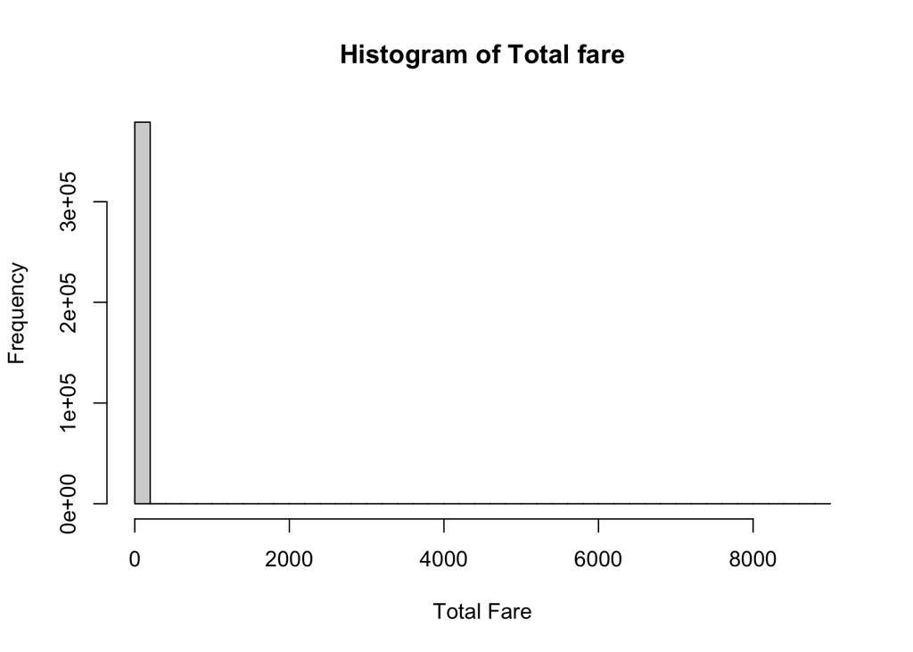

```r
hist(Trip.Total, breaks = 50, main = "Histogram of Total fare", xlab = "Total Fare")
```

```r
summary(Trip.Total)
```

```
##    Min. 1st Qu.  Median    Mean 3rd Qu.    Max.
##    0.00    9.75   16.50   24.86   36.30 8912.13
```

Looking at the histogram and the boxplot, there are some extreme values that hinders accuracy of our future model, hence needs to be removed.

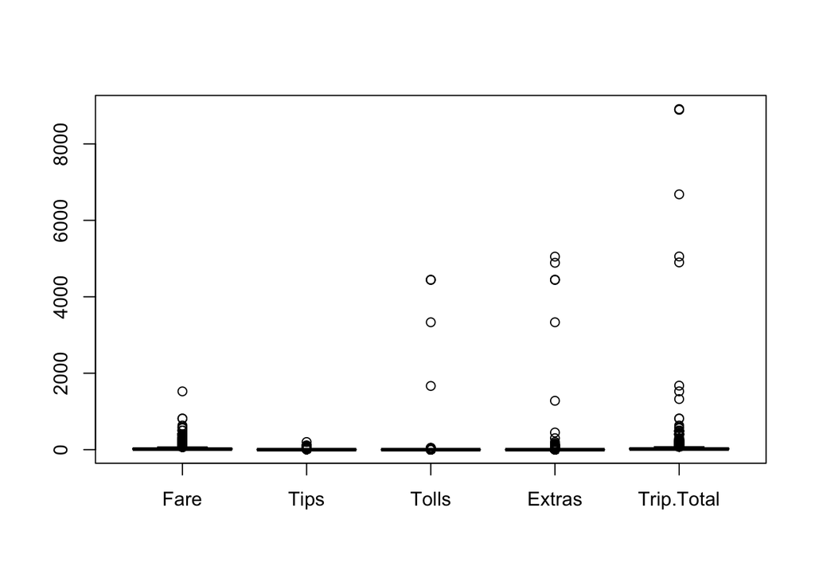

```r
fare_related_features <- cleaned_taxi_df[, c('Fare','Tips','Tolls','Extras','Trip.Total')]
boxplot(fare_related_features)
```

```r
# Define the function to detect outliers for a single column
is.outlier <- function(x) {
  iqr <- IQR(x, na.rm = TRUE)
  lower <- quantile(x, 0.25, na.rm = TRUE) - 1.5 * iqr
  upper <- quantile(x, 0.75, na.rm = TRUE) + 1.5 * iqr
  return(x < lower | x > upper)
}

outliers <- is.outlier(Trip.Total)
```

number of outliers

```r
sum(outliers)
```

```
## [1] 3889
```

Remove all the rows that are outliers of Trip.Total

```r
cleaned_taxi_df <- cleaned_taxi_df[!outliers, ]
dim(cleaned_taxi_df)
```

```
## [1] 375135     17
```

### 2.2 Histrogram of each features

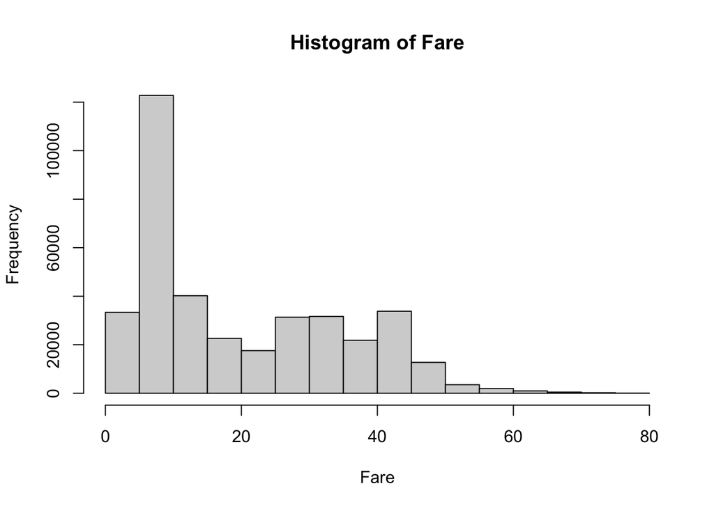

```r
hist(cleaned_taxi_df$Fare, breaks = 25, main = "Histogram of Fare", xlab = "Fare")
```

```r
summary(cleaned_taxi_df$Fare)
```

```
##    Min. 1st Qu.  Median    Mean 3rd Qu.    Max.
##    0.00    7.75   13.75   20.13   31.75   76.00
```

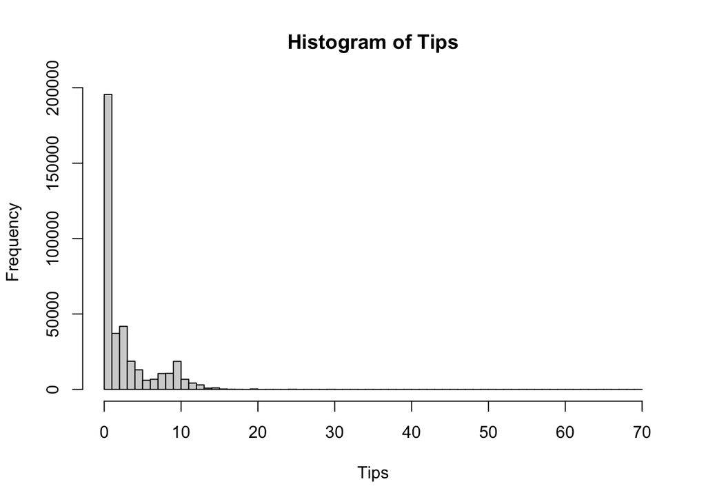

```r
hist(cleaned_taxi_df$Tips, breaks = 50, main = "Histogram of Tips", xlab = "Tips")
```

```r
summary(cleaned_taxi_df$Tips)
```

```
##    Min. 1st Qu.  Median    Mean 3rd Qu.    Max.
##   0.000   0.000   0.000   2.507   3.550  70.000
```

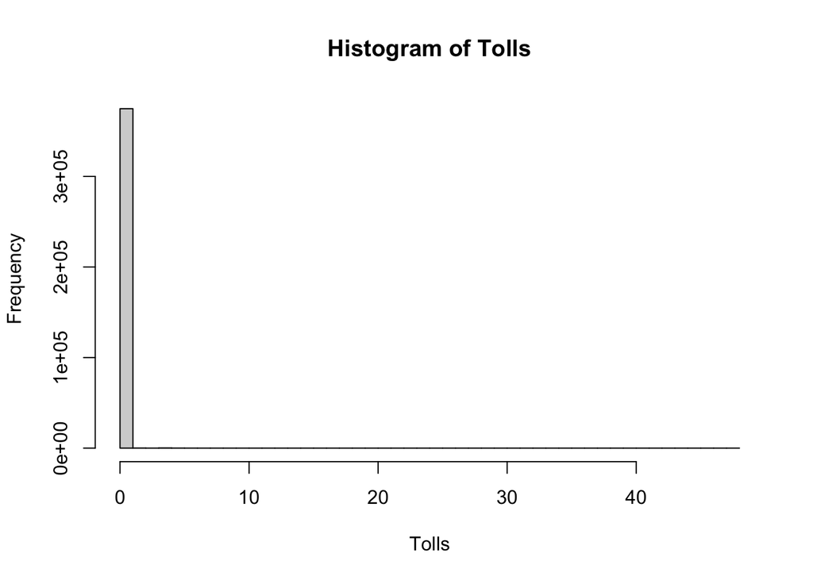

```r
hist(cleaned_taxi_df$Tolls, breaks = 50, main = "Histogram of Tolls", xlab = "Tolls")
```

```r
summary(cleaned_taxi_df$Tolls)
```

```
##     Min.  1st Qu.   Median     Mean  3rd Qu.     Max.
##  0.00000  0.00000  0.00000  0.00453  0.00000 48.00000
```

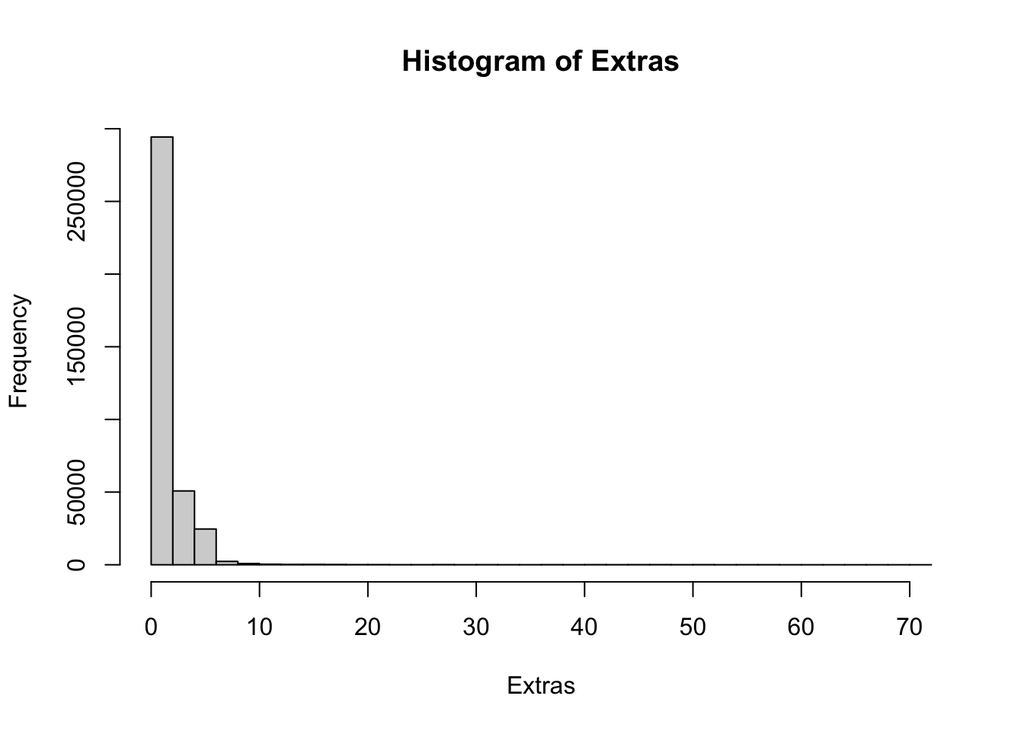

```r
hist(cleaned_taxi_df$Extras, breaks = 50, main = "Histogram of Extras", xlab = "Extras")
```

```r
summary(cleaned_taxi_df$Extras)
```

```
##    Min. 1st Qu.  Median    Mean 3rd Qu.    Max.
##   0.000   0.000   0.000   1.199   1.000  72.000
```

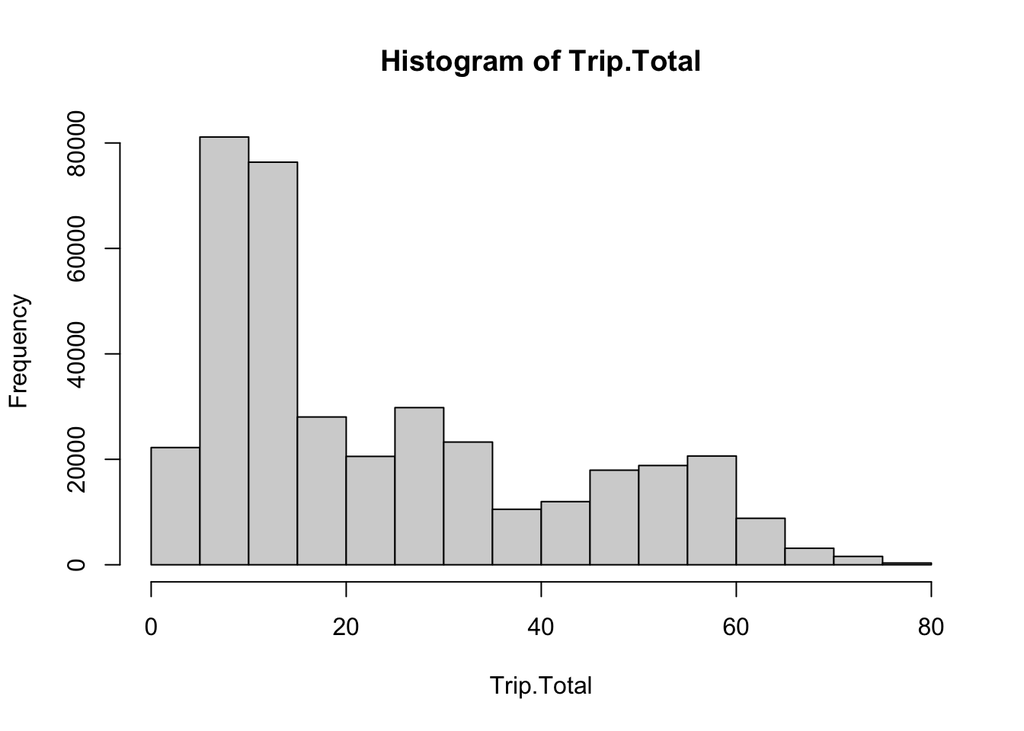

```r
hist(cleaned_taxi_df$Trip.Total, breaks = 25, main = "Histogram of Trip.Total", xlab = "Trip.Total")
```

```r
summary(cleaned_taxi_df$Trip.Total)
```

```
##    Min. 1st Qu.  Median    Mean 3rd Qu.    Max.
##    0.00    9.50   16.25   24.01   35.00   76.05
```

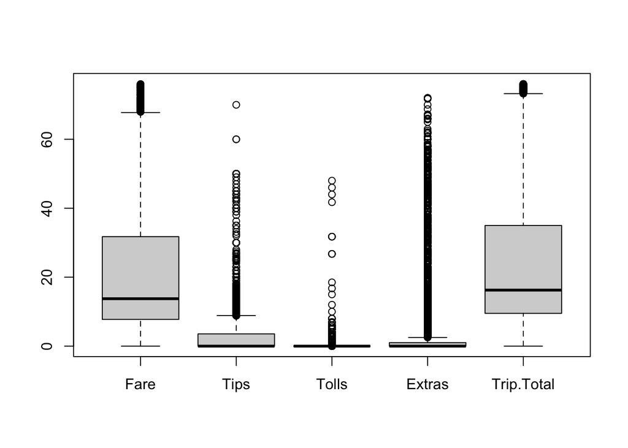

```r
boxplot(cleaned_taxi_df[, c('Fare','Tips','Tolls','Extras','Trip.Total')])
```

### 2.3 Heatmap of correlation of each features

```r
# Select only numeric columns for correlation
numeric_columns <- sapply(cleaned_taxi_df, is.numeric)
cor_matrix <- cor(cleaned_taxi_df[, numeric_columns], use = "complete.obs")

print(cor_matrix)
```

```
##                      Trip.Miles       Fare       Tips         Tolls
## Trip.Miles           1.00000000 0.84004896 0.46749790  1.323617e-02
## Fare                 0.84004896 1.00000000 0.50713396  1.017268e-02
## Tips                 0.46749790 0.50713396 1.00000000  1.559658e-02
## Tolls                0.01323617 0.01017268 0.01559658  1.000000e+00
## Extras               0.31762504 0.31177482 0.38864411 -6.985914e-05
## Trip.Total           0.82845693 0.96424450 0.67724999  2.406436e-02
## Trip.Minutes         0.40196754 0.45073709 0.19767514  3.401189e-03
## Trip.Hour.Of.The.Day 0.05298319 0.05839975 0.09499803  1.705053e-03
##                             Extras Trip.Total Trip.Minutes Trip.Hour.Of.The.Day
## Trip.Miles            3.176250e-01 0.82845693  0.401967535          0.052983193
## Fare                  3.117748e-01 0.96424450  0.450737087          0.058399754
## Tips                  3.886441e-01 0.67724999  0.197675144          0.094998035
## Tolls                -6.985914e-05 0.02406436  0.003401189          0.001705053
## Extras                1.000000e+00 0.49444261  0.133194004          0.099926738
## Trip.Total            4.944426e-01 1.00000000  0.426929339          0.082680457
## Trip.Minutes          1.331940e-01 0.42692934  1.000000000          0.046674751
## Trip.Hour.Of.The.Day  9.992674e-02 0.08268046  0.046674751          1.000000000
```

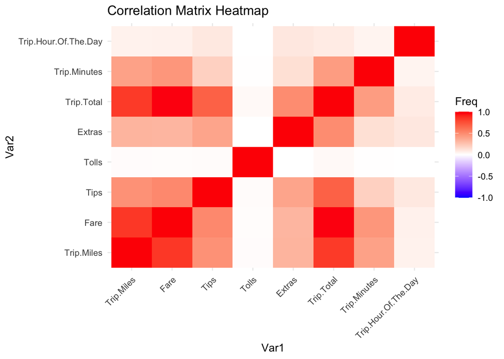

```r
# Convert the correlation matrix to a long format for ggplot2
cor_data <- as.data.frame(as.table(cor_matrix))

# Create a heatmap with ggplot2
ggplot(cor_data, aes(Var1, Var2, fill = Freq)) +
  geom_tile() +
  scale_fill_gradient2(low = "blue", high = "red", mid = "white", midpoint = 0, limit = c(-1,1)) +
  theme_minimal() +
  theme(axis.text.x = element_text(angle = 45, hjust = 1)) +
  ggtitle("Correlation Matrix Heatmap")
```

Trip.Total is in high correlation relationship with ‘Fare, Trip.Miles, Tips’, but almost no relationship with ‘Tolls, Hour of the trip’

### 2.4 Other data exploration

#### 1) Average Number of Trips per Taxi in a Day Over Time

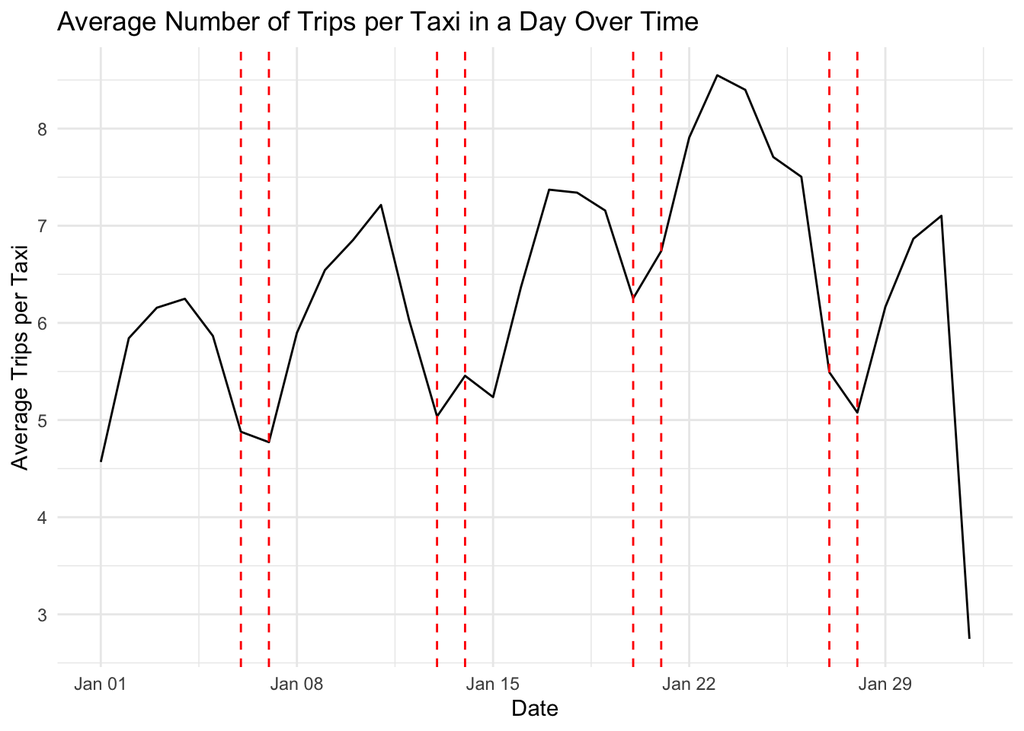

```r
# Generate a sequence of dates within the range of your data
date_range <- seq(min(cleaned_taxi_df$Trip.Start.Date), max(cleaned_taxi_df$Trip.Start.Date), by = "day")

# Create a data frame of weekend dates
weekend_dates <- data.frame(Date = date_range[weekdays(date_range) %in% c("Saturday", "Sunday")])

# Group by Taxi ID and Date, then summarize the average trips
average_trips_per_taxi <- cleaned_taxi_df %>%
  group_by(Taxi.ID, Trip.Start.Date) %>%
  summarise(Trips = n(), .groups = 'drop') %>%
  group_by(Trip.Start.Date) %>%
  summarise(AvgTrips = mean(Trips), .groups = 'drop')

# Plot the average trips per taxi over time
plot <- ggplot(average_trips_per_taxi, aes(x = Trip.Start.Date, y = AvgTrips)) +
  geom_line() +
  labs(title = "Average Number of Trips per Taxi in a Day Over Time",
       x = "Date",
       y = "Average Trips per Taxi") +
  theme_minimal()

# Add vertical lines for weekends
plot + geom_vline(data = weekend_dates, aes(xintercept = as.numeric(Date)), color = "red", linetype = "dashed")
```

#### 2) Total Trips Over Time

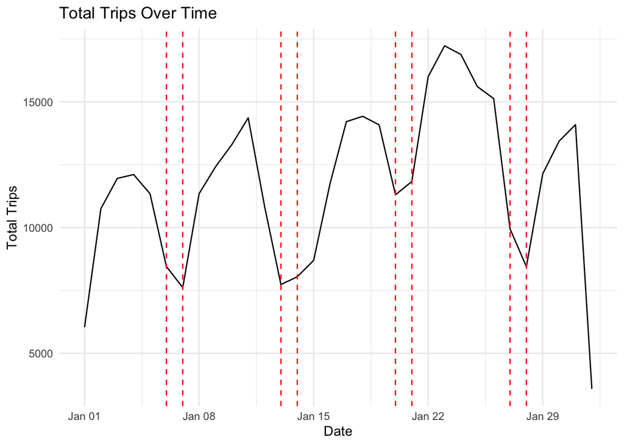

```r
# First, calculate the total trips per day
total_trips_over_time <- cleaned_taxi_df %>%
  group_by(Trip.Start.Date) %>%
  summarise(TotalTrips = n(), .groups = 'drop')

# Plot the total trips over time
total_trips_plot <- ggplot(total_trips_over_time, aes(x = Trip.Start.Date, y = TotalTrips)) +
  geom_line() +
  labs(title = "Total Trips Over Time",
       x = "Date",
       y = "Total Trips") +
  theme_minimal()

# Add vertical lines for weekends
total_trips_plot + geom_vline(data = weekend_dates, aes(xintercept = as.numeric(Date)), color = "red", linetype = "dashed")
```

We can see that people tends not to use taxi on weekends than weekdays.

#### 3) Pickup and Dropoff Area Count - Overlaid Histogram

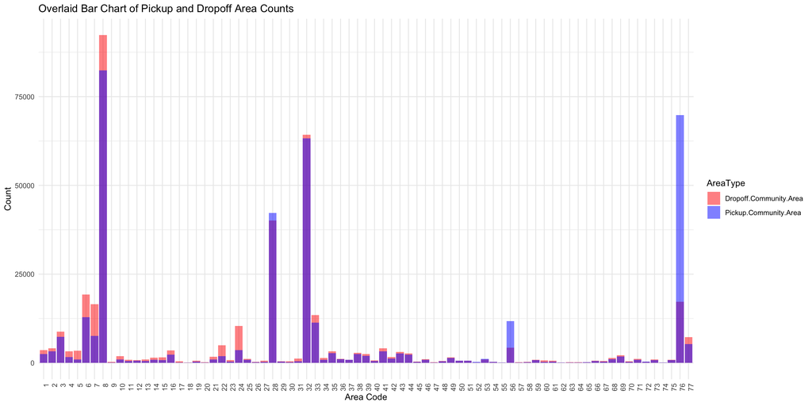

```r
# Create a long format data frame for pickup and dropoff areas
area_data <- tidyr::pivot_longer(
  cleaned_taxi_df,
  cols = c("Pickup.Community.Area", "Dropoff.Community.Area"),
  names_to = "AreaType",
  values_to = "Area"
)

# Plot overlaid bar charts for pickup and dropoff area counts
ggplot(area_data, aes(x = as.factor(Area), fill = AreaType)) +
  geom_bar(position = "identity", alpha = 0.5) +  # Set alpha for transparency
  scale_fill_manual(values = c("Pickup.Community.Area" = "blue", "Dropoff.Community.Area" = "red")) +
  labs(title = "Overlaid Bar Chart of Pickup and Dropoff Area Counts",
       x = "Area Code",
       y = "Count") +
  theme_minimal() +
  theme(axis.text.x = element_text(angle = 90, hjust = 1))
```

#### 4) Trip.Total by Payment Type

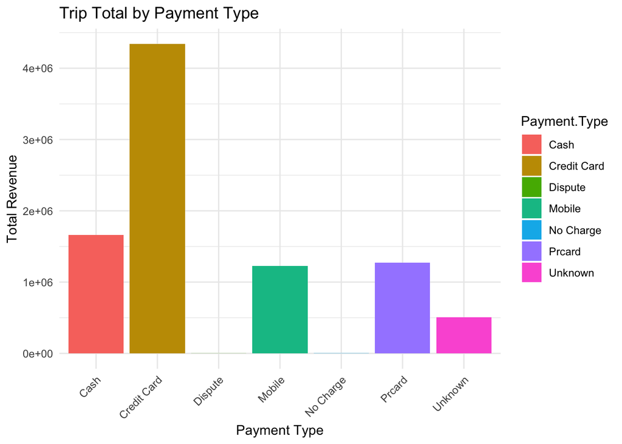

```r
# Summarise Trip.Total by Payment Type
trip_total_by_PaymentType <- cleaned_taxi_df %>%
  group_by(Payment.Type) %>%
  summarise(TotalRevenue = sum(Trip.Total), .groups = 'drop')

# Create a bar plot of Trip Total by Payment Type
ggplot(trip_total_by_PaymentType, aes(x = Payment.Type, y = TotalRevenue, fill = Payment.Type)) +
  geom_col() +  # This creates a bar chart with pre-summarized data
  labs(title = "Trip Total by Payment Type",
       x = "Payment Type",
       y = "Total Revenue") +
  theme_minimal() +
  theme(axis.text.x = element_text(angle = 45, hjust = 1))
```

#### 5) Trip.Total by Day of the week

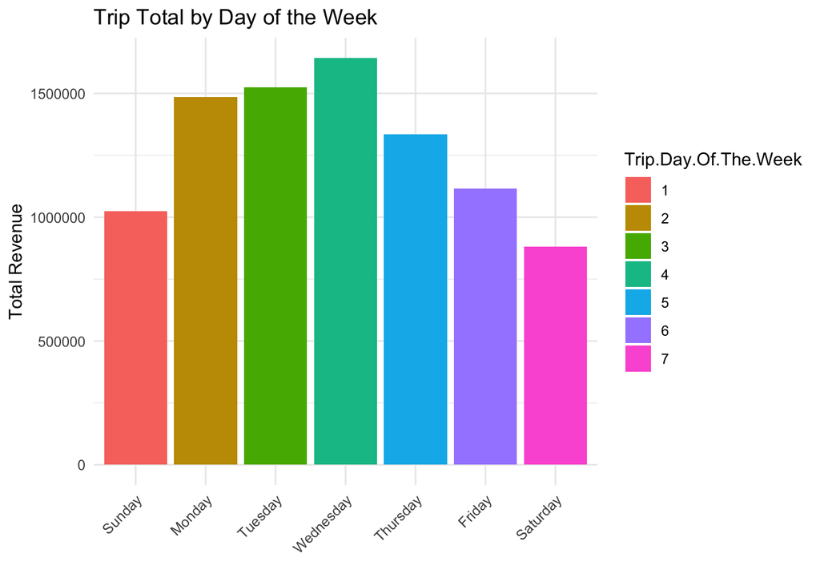

```r
trip_total_by_DayoftheWeek <- cleaned_taxi_df %>%
  group_by(Trip.Day.Of.The.Week) %>%
  summarise(TotalRevenue = sum(Trip.Total), .groups = 'drop')

# Define a named vector to map day numbers to day names
day_names <- c("1" = "Sunday", "2" = "Monday", "3" = "Tuesday", "4" = "Wednesday",
               "5" = "Thursday", "6" = "Friday", "7" = "Saturday")

# Create the bar plot, using the named vector for axis labels
ggplot(trip_total_by_DayoftheWeek, aes(x = Trip.Day.Of.The.Week, y = TotalRevenue, fill = Trip.Day.Of.The.Week)) +
  geom_col() +
  scale_x_discrete(labels = day_names) +  # Use the day_names vector for axis labels
  labs(title = "Trip Total by Day of the Week",
       x = " ",
       y = "Total Revenue") +
  theme_minimal() +
  theme(axis.text.x = element_text(angle = 45, hjust = 1))
```

#### 6) Trip.Total by Company

```r
# Summarise Trip.Total by Company and arrange by TotalRevenue in descending order
trip_total_by_Company <- cleaned_taxi_df %>%
  group_by(Company) %>%
  summarise(TotalRevenue = sum(Trip.Total), .groups = 'drop') %>%
  arrange(desc(TotalRevenue))

# Display the full table sorted by Total Revenue
kable(trip_total_by_Company)
```

| Company | TotalRevenue |
| --- | --- |
| Flash Cab | 1990169.36 |
| Taxi Affiliation Services | 1675736.31 |
| Taxicab Insurance Agency Llc | 1006494.48 |
| Sun Taxi | 1006423.09 |
| City Service | 817276.91 |
| Chicago Independents | 556686.13 |
| 5 Star Taxi | 482365.54 |
| Globe Taxi | 331868.53 |
| Blue Ribbon Taxi Association | 271361.15 |
| Medallion Leasin | 253900.09 |
| Taxicab Insurance Agency, LLC | 151921.61 |
| Choice Taxi Association | 106725.28 |
| Choice Taxi Association Inc | 79464.05 |
| Chicago City Taxi Association | 64120.54 |
| U Taxicab | 48885.16 |
| Top Cab | 32126.52 |
| Koam Taxi Association | 18369.99 |
| Chicago Taxicab | 17667.09 |
| Taxi Affiliation Services Llc - Yell | 16331.27 |
| Star North Taxi Management Llc | 15055.09 |
| 312 Medallion Management Corp | 13741.55 |
| Patriot Taxi Dba Peace Taxi Associat | 10606.40 |
| Setare Inc | 10504.64 |
| Metro Jet Taxi A. | 6202.93 |
| 5167 - 71969 5167 Taxi Inc | 4909.89 |
| 3591 - 63480 Chuks Cab | 3561.23 |
| Petani Cab Corp | 3191.65 |
| 6574 - Babylon Express Inc. | 2965.80 |
| Tac - Yellow Cab Association | 2710.99 |
| 4053 - 40193 Adwar H. Nikola | 2392.50 |
| 2733 - 74600 Benny Jona | 2122.88 |
| 3556 - 36214 RC Andrews Cab | 1712.25 |
| Tac - Checker Cab Dispatch | 991.72 |

#### 7) Trips Count by Paymeny type

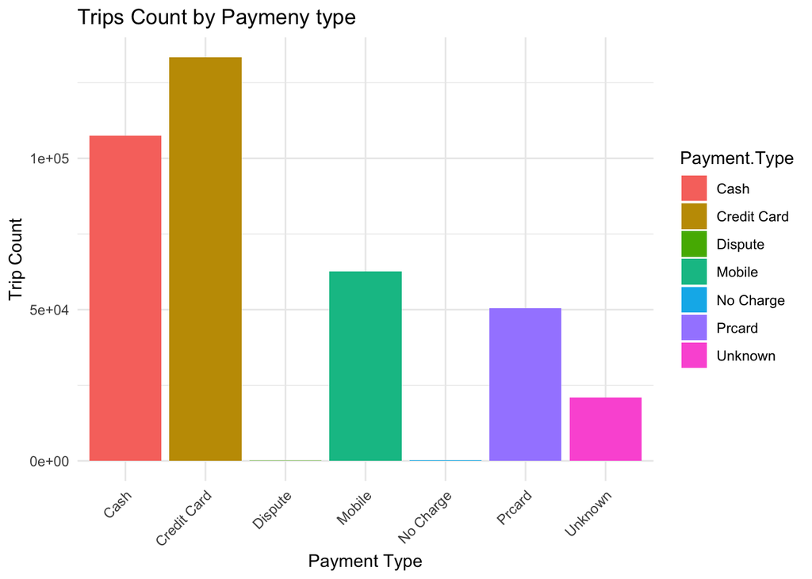

```r
# Summarise Trip id by Payment Type
trip_count_by_PaymentType <- cleaned_taxi_df %>%
  group_by(Payment.Type) %>%
  summarise(TripCount = n_distinct(Trip.ID))

# Create a bar plot of Trip Total by Payment Type
ggplot(trip_count_by_PaymentType, aes(x = Payment.Type, y = TripCount, fill = Payment.Type)) +
  geom_col() +  # This creates a bar chart with pre-summarized data
  labs(title = "Trips Count by Paymeny type",
       x = "Payment Type",
       y = "Trip Count") +
  theme_minimal() +
  theme(axis.text.x = element_text(angle = 45, hjust = 1))
```

#### 8) Trips Count by day of the week

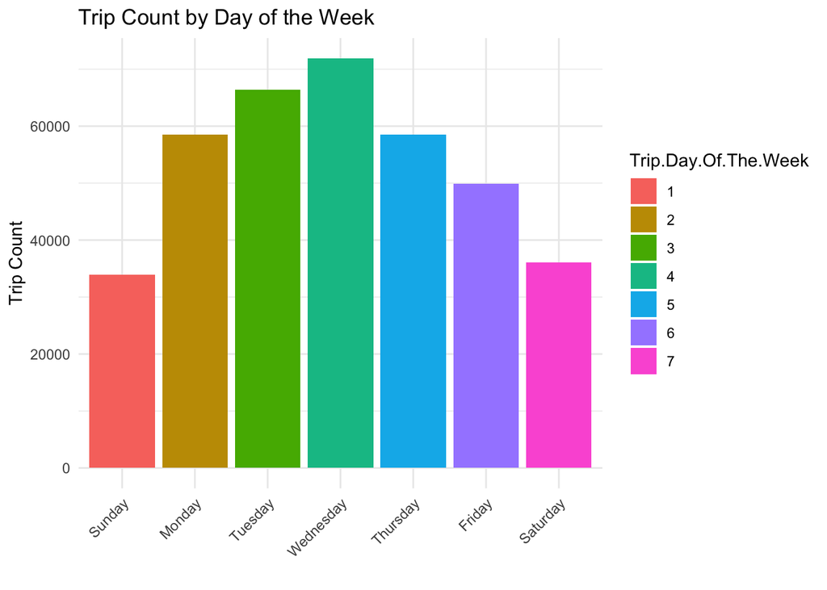

```r
trip_count_by_DayoftheWeek <- cleaned_taxi_df %>%
  group_by(Trip.Day.Of.The.Week) %>%
  summarise(TripCount = n_distinct(Trip.ID))

# Define a named vector to map day numbers to day names
day_names <- c("1" = "Sunday", "2" = "Monday", "3" = "Tuesday", "4" = "Wednesday",
               "5" = "Thursday", "6" = "Friday", "7" = "Saturday")

# Create the bar plot, using the named vector for axis labels
ggplot(trip_count_by_DayoftheWeek, aes(x = Trip.Day.Of.The.Week, y = TripCount, fill = Trip.Day.Of.The.Week)) +
  geom_col() +
  scale_x_discrete(labels = day_names) +  # Use the day_names vector for axis labels
  labs(title = "Trip Count by Day of the Week",
       x = " ",
       y = "Trip Count") +
  theme_minimal() +
  theme(axis.text.x = element_text(angle = 45, hjust = 1))
```

#### 9) Trips Count by Company

```r
# Summarise Trip.Total by Company and arrange by TotalRevenue in descending order
trip_count_by_Company <- cleaned_taxi_df %>%
  group_by(Company) %>%
  summarise(TripCount = n_distinct(Trip.ID), .groups = 'drop') %>%
  arrange(desc(TripCount))

# Display the full table sorted by Total Revenue
kable(trip_count_by_Company)
```

| Company | TripCount |
| --- | --- |
| Flash Cab | 86155 |
| Taxi Affiliation Services | 70815 |
| Sun Taxi | 39892 |
| Taxicab Insurance Agency Llc | 38976 |
| City Service | 35099 |
| Chicago Independents | 21511 |
| 5 Star Taxi | 16979 |
| Globe Taxi | 14263 |
| Blue Ribbon Taxi Association | 12996 |
| Medallion Leasin | 11036 |
| Taxicab Insurance Agency, LLC | 6118 |
| Choice Taxi Association | 4194 |
| Chicago City Taxi Association | 3765 |
| Choice Taxi Association Inc | 3232 |
| U Taxicab | 2316 |
| Top Cab | 1629 |
| Koam Taxi Association | 1138 |
| Taxi Affiliation Services Llc - Yell | 829 |
| Patriot Taxi Dba Peace Taxi Associat | 762 |
| Chicago Taxicab | 666 |
| Star North Taxi Management Llc | 628 |
| Setare Inc | 412 |
| 312 Medallion Management Corp | 347 |
| 3591 - 63480 Chuks Cab | 328 |
| Metro Jet Taxi A. | 299 |
| Tac - Yellow Cab Association | 182 |
| 5167 - 71969 5167 Taxi Inc | 176 |
| 3556 - 36214 RC Andrews Cab | 91 |
| 6574 - Babylon Express Inc. | 82 |
| Petani Cab Corp | 67 |
| Tac - Checker Cab Dispatch | 58 |
| 4053 - 40193 Adwar H. Nikola | 51 |
| 2733 - 74600 Benny Jona | 43 |

Some Key Findings from EDA

1. Total taxi fare correlates with original fare, trip miles, tips, where does not correlates with tolls and trip hours of the day.
2. People tends to use taxi on weekdays (especially on Wed > Tue > Mon), but not on weenkends.
3. Majority of people use Credit Card then Cash to pay the taxi fare.
4. The most popular Pickup area are ‘8, 76, 32, 28’.
5. The most popular Dropoff area are ‘8, 32, 28’.
6. Top 5 most frequently used taxi companies in Chicago are Flash Cab, Taxi Affiliation Services, Sun Taxi, Taxicab Insurance Agency Llc, and City Service.